# Starbucks Capstone Challenge

# 1. Business Understanding

## Introduction

This data set contains simulated data that mimics customer behavior on the Starbucks rewards mobile app. Once every few days, Starbucks sends out an offer to users of the mobile app. An offer can be merely an advertisement for a drink or an actual offer such as a discount or BOGO (buy one get one free). Some users might not receive any offer during certain weeks.

Not all users receive the same offer, and that is the challenge to solve with this data set.

Your task is to combine transaction, demographic and offer data to determine which demographic groups respond best to which offer type. This data set is a simplified version of the real Starbucks app because the underlying simulator only has one product whereas Starbucks actually sells dozens of products.

Every offer has a validity period before the offer expires. As an example, a BOGO offer might be valid for only 5 days. You'll see in the data set that informational offers have a validity period even though these ads are merely providing information about a product; for example, if an informational offer has 7 days of validity, you can assume the customer is feeling the influence of the offer for 7 days after receiving the advertisement.

You'll be given transactional data showing user purchases made on the app including the timestamp of purchase and the amount of money spent on a purchase. This transactional data also has a record for each offer that a user receives as well as a record for when a user actually views the offer. There are also records for when a user completes an offer.

Keep in mind as well that someone using the app might make a purchase through the app without having received an offer or seen an offer.

**Example**

To give an example, a user could receive a discount offer buy 10 dollars get 2 off on Monday. The offer is valid for 10 days from receipt. If the customer accumulates at least 10 dollars in purchases during the validity period, the customer completes the offer.

However, there are a few things to watch out for in this data set. Customers do not opt into the offers that they receive; in other words, a user can receive an offer, never actually view the offer, and still complete the offer. For example, a user might receive the "buy 10 dollars get 2 dollars off offer", but the user never opens the offer during the 10 day validity period. The customer spends 15 dollars during those ten days. There will be an offer completion record in the data set; however, the customer was not influenced by the offer because the customer never viewed the offer.

**Datasets**

The data is contained in three files:

- portfolio.json - containing offer ids and meta data about each offer (duration, type, etc.)
- profile.json - demographic data for each customer
- transcript.json - records for transactions, offers received, offers viewed, and offers completed

## Problem Statement

The main question is can the portfolio of offers been improved, or can we better target certain offers to certain users, in order to increase the amount spend. To answer this I will aim to answer the following three questions throughout this notebook.

**1. What demographics is represented by the provided dataset?**

**2. What offers exist and how are those distributed?**

**3. When sending out future offers, who will respond better to offers (What offers work best for who)?**

# 2. Data Understanding

```python
# Below is a general import section
import pandas as pd
import numpy as np
import math
import json
import matplotlib.pyplot as plt
import seaborn as sns
import os
from tqdm import tqdm
from helperfunctions import *

from sklearn.linear_model import LinearRegression
from sklearn.model_selection import train_test_split
from sklearn.metrics import r2_score, mean_squared_error
from sklearn.decomposition import PCA
from sklearn.preprocessing import StandardScaler


sns.set(rc={'figure.figsize':(16,10)})
sns.set_style("whitegrid")

import warnings
warnings.filterwarnings('ignore')
```

The first step of this analysis is to get an overview of the available datasets on hand. For this reason we first analyze the size of the dataset and look into the attributes, as well as we can identify some outliers by looking at the data.

## 2.1 Loading in the dataset

```python
portfolio = pd.read_json('data/portfolio.json', orient='records', lines=True)
profile = pd.read_json('data/profile.json', orient='records', lines=True)
transcript = pd.read_json('data/transcript.json', orient='records', lines=True)
```

```python
print("Shape of portfolio dataframe:", portfolio.shape)
print("Shape of profile dataframe:", profile.shape)
print("Shape of transcript dataframe:", transcript.shape)
```

```
Shape of portfolio dataframe: (10, 6)
Shape of profile dataframe: (17000, 5)
Shape of transcript dataframe: (306534, 4)
```

```python
portfolio
```

|  | channels | difficulty | duration | id | offer_type | reward |
| --- | --- | --- | --- | --- | --- | --- |
| 0 | [email, mobile, social] | 10 | 7 | ae264e3637204a6fb9bb56bc8210ddfd | bogo | 10 |
| 1 | [web, email, mobile, social] | 10 | 5 | 4d5c57ea9a6940dd891ad53e9dbe8da0 | bogo | 10 |
| 2 | [web, email, mobile] | 0 | 4 | 3f207df678b143eea3cee63160fa8bed | informational | 0 |
| 3 | [web, email, mobile] | 5 | 7 | 9b98b8c7a33c4b65b9aebfe6a799e6d9 | bogo | 5 |
| 4 | [web, email] | 20 | 10 | 0b1e1539f2cc45b7b9fa7c272da2e1d7 | discount | 5 |
| 5 | [web, email, mobile, social] | 7 | 7 | 2298d6c36e964ae4a3e7e9706d1fb8c2 | discount | 3 |
| 6 | [web, email, mobile, social] | 10 | 10 | fafdcd668e3743c1bb461111dcafc2a4 | discount | 2 |
| 7 | [email, mobile, social] | 0 | 3 | 5a8bc65990b245e5a138643cd4eb9837 | informational | 0 |
| 8 | [web, email, mobile, social] | 5 | 5 | f19421c1d4aa40978ebb69ca19b0e20d | bogo | 5 |
| 9 | [web, email, mobile] | 10 | 7 | 2906b810c7d4411798c6938adc9daaa5 | discount | 2 |

**portfolio.json**

- id (string) - offer id
- offer_type (string) - type of offer ie BOGO (Buy one get one), discount, informational
- difficulty (int) - minimum required spend to complete an offer
- reward (int) - reward given for completing an offer
- duration (int) - time for offer to be open, in days
- channels (list of strings)

```python
profile.head()
```

|  | age | became_member_on | gender | id | income |
| --- | --- | --- | --- | --- | --- |
| 0 | 118 | 20170212 | None | 68be06ca386d4c31939f3a4f0e3dd783 | NaN |
| 1 | 55 | 20170715 | F | 0610b486422d4921ae7d2bf64640c50b | 112000.0 |
| 2 | 118 | 20180712 | None | 38fe809add3b4fcf9315a9694bb96ff5 | NaN |
| 3 | 75 | 20170509 | F | 78afa995795e4d85b5d9ceeca43f5fef | 100000.0 |
| 4 | 118 | 20170804 | None | a03223e636434f42ac4c3df47e8bac43 | NaN |

**profile.json**

- age (int) - age of the customer, but 118 looks a bit high
- became_member_on (int) - date when customer created an app account
- gender (str) - gender of the customer (note some entries contain 'O' for other rather than M or F)
- id (str) - customer id
- income (float) - customer's income

```python
transcript.head()
```

|  | event | person | time | value |
| --- | --- | --- | --- | --- |
| 0 | offer received | 78afa995795e4d85b5d9ceeca43f5fef | 0 | {'offer id': '9b98b8c7a33c4b65b9aebfe6a799e6d9'} |
| 1 | offer received | a03223e636434f42ac4c3df47e8bac43 | 0 | {'offer id': '0b1e1539f2cc45b7b9fa7c272da2e1d7'} |
| 2 | offer received | e2127556f4f64592b11af22de27a7932 | 0 | {'offer id': '2906b810c7d4411798c6938adc9daaa5'} |
| 3 | offer received | 8ec6ce2a7e7949b1bf142def7d0e0586 | 0 | {'offer id': 'fafdcd668e3743c1bb461111dcafc2a4'} |
| 4 | offer received | 68617ca6246f4fbc85e91a2a49552598 | 0 | {'offer id': '4d5c57ea9a6940dd891ad53e9dbe8da0'} |

**transcript.json**

- event (str) - record description (ie transaction, offer received, offer viewed, etc.)
- person (str) - customer id
- time (int) - time in hours since start of test. The data begins at time t=0
- value - (dict of strings) - either an offer id or transaction amount depending on the record

## 2.2 Data exploration

The first thing for the data exploration step will be to identify outliers and get a better understanding for the distribution of the values within each dataset. Specifically the profile dataset will be used to show what kind of demographic is represented by the data

### Profile data

```python
profile.shape
```

```
(17000, 5)
```

```python
profile.isnull().sum()
```

```
age                    0
became_member_on       0
gender              2175
id                     0
income              2175
dtype: int64
```

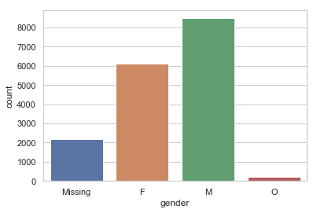

```python
sns.countplot(x='gender', data=profile.fillna('Missing'))
```

```python
profile[profile.age==118].count()
```

```
age                 2175
became_member_on    2175
gender                 0
id                  2175
income                 0
dtype: int64
```

```python
profile[profile.age==118].isna().sum()
```

```
age                    0
became_member_on       0
gender              2175
id                     0
income              2175
dtype: int64
```

As I already saw in the beginning by peaking at the data, there were some entries with age 118. Obviously this cannot be true. By looking at the data, it becomes definately clear, that those values are all part of the misisng data. Moving on I will seperate this data from the rest, as I can't pull any demographic data from here.

```python
profile_nona = profile.dropna()
profile_na = profile.loc[profile['age'] == 118]
```

```python
1 - 14824/17000
```

```
0.128
```

```python
print(profile_nona.shape)
print(profile_na.shape)
```

```
(14825, 5)
(2175, 5)
```

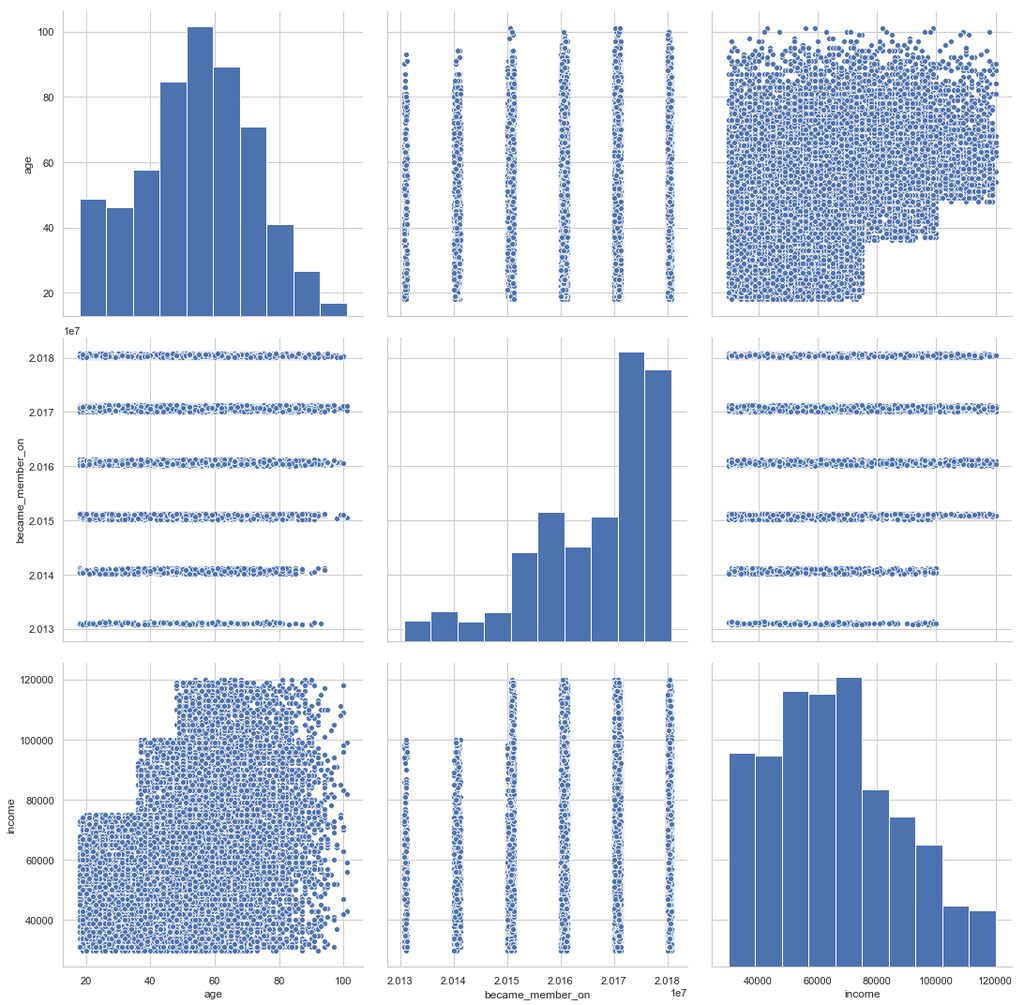

```python
sns.pairplot(profile_nona, size=5)
```

[output not shown]

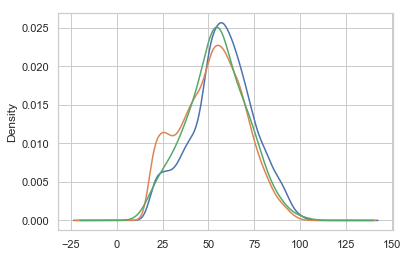

```python
profile.groupby(['gender']).age.plot(kind="kde")
```

```
gender
F    AxesSubplot(0.125,0.125;0.775x0.755)
M    AxesSubplot(0.125,0.125;0.775x0.755)
O    AxesSubplot(0.125,0.125;0.775x0.755)
Name: age, dtype: object
```

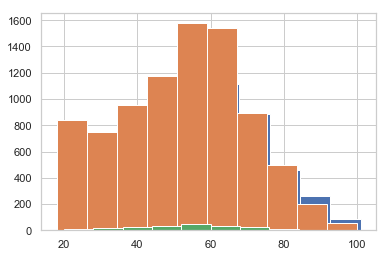

```python
profile_nona.groupby(['gender']).age.hist()
```

```python
# make the age variable discretized
profile_nona['age_bin'] = pd.cut(profile_nona['age'], 10)
profile_nona['income_bin'] = pd.cut(profile_nona['income'], 10)
```

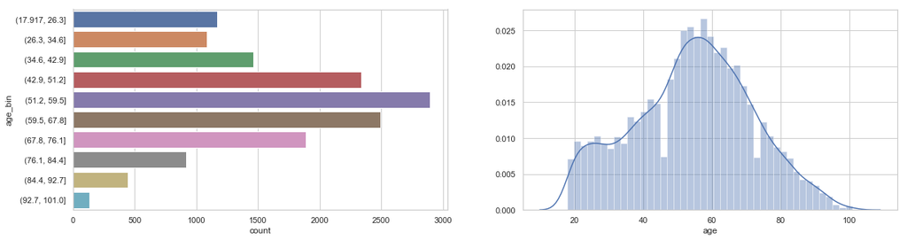

```python
fig = plt.figure(figsize=(20,5))
plt.subplot(1, 2, 1)
sns.countplot(y="age_bin", data=profile_nona)
plt.subplot(1, 2, 2)
sns.distplot(profile_nona.age)
```

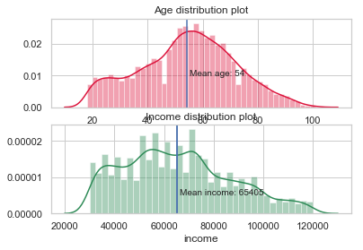

```python
f, axes = plt.subplots(2, 1)
sns.distplot(profile_nona.age, color= 'crimson', ax=axes[0])
sns_income_distplot = sns.distplot(profile_nona.income, color = 'seagreen', ax=axes[1])
axes[0].axvline(x=profile_nona.age.mean())
axes[0].text(profile_nona.age.mean()+1,0.01,"Mean age: {:.0f}".format(profile_nona.age.mean()),rotation=0)
axes[0].set_title('Age distribution plot')
axes[1].axvline(x=profile_nona.income.mean())
axes[1].axvline(x=profile_nona.income.mean())
axes[1].text(profile_nona.income.mean()+1000,0.000005,"Mean income: {:.0f}".format(profile_nona.income.mean()),rotation=0)
axes[1].set_title('Income distribution plot')
f.savefig('AgeIncome_dist.png')
```

```python
palette = dict(F = 'darkgrey', M = 'seagreen', O = 'crimson')
```

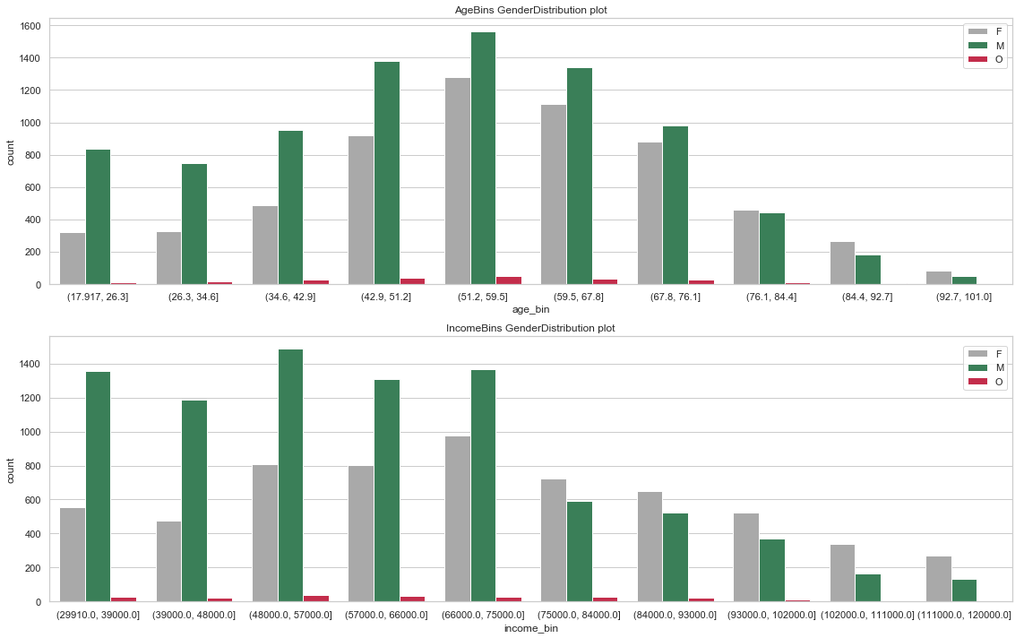

```python
f, axes = plt.subplots(2, 1, figsize=(16,10))
sns.countplot(x='age_bin', hue='gender', palette=palette, data=profile_nona, ax=axes[0])
sns.countplot(x='income_bin', hue='gender', palette=palette, data=profile_nona, ax=axes[1])
axes[0].set_title('AgeBins GenderDistribution plot')
axes[0].legend(loc='top right', bbox_to_anchor=(1, 1))
axes[1].set_title('IncomeBins GenderDistribution plot')
axes[1].legend(loc='center right', bbox_to_anchor=(1, 0.88))
f.tight_layout()
f.savefig('AgeIncome_Gender_countplot.png')
```

```python
# Engineering the became member on. We want to keep the year and the total number of months
profile_nona['became_member_on'] = pd.to_datetime(profile_nona['became_member_on'], format='%Y%m%d')
profile_nona['MemberSince'] = profile_nona.became_member_on.dt.year
profile_nona['MembershipInMonths'] = pd.to_datetime('20180926',format='%Y%m%d')
profile_nona['MembershipInMonths'] = round(((profile_nona.MembershipInMonths - profile_nona.became_member_on)/np.timedelta64(1, 'M')))
profile_nona.drop(columns='became_member_on', inplace=True)
```

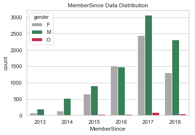

```python
sns_MemberSince_plot = sns.countplot(x='MemberSince', hue='gender', palette=palette, data=profile_nona)
sns_MemberSince_plot.set_title('MemberSince Data Distribution')
fig = sns_MemberSince_plot.get_figure()
fig.savefig('MemberSince.png')
```

```python
profile['became_member_on'] = pd.to_datetime(profile['became_member_on'], format='%Y%m%d')
```

```python
profile['became_member_on'].sort_values(ascending=False).head()
```

```
4357    2018-07-26
12902   2018-07-26
10282   2018-07-26
12326   2018-07-26
8079    2018-07-26
Name: became_member_on, dtype: datetime64[ns]
```

```python
gender = profile_nona.groupby('gender')['MemberSince'].value_counts()
genderdf = pd.DataFrame(data={'val': gender}).reset_index()
genderdf.update(genderdf.loc[genderdf.MemberSince==2018]['val'].transform(lambda x: x*12/8))
```

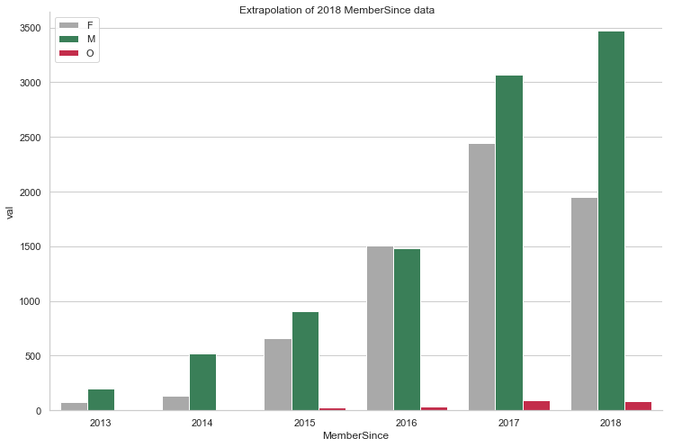

```python
## Pandas version to unstack multi index
##genderdf.unstack(level=0).plot(kind='bar')

sns_MemberSince_extrapolated_plot = sns.factorplot(x='MemberSince', y='val', hue='gender',
                        data=genderdf, kind='bar', palette=palette, size=7, aspect=1.5, legend=False)
sns_MemberSince_extrapolated_plot.axes[0][0].legend()
sns_MemberSince_extrapolated_plot.fig.suptitle("Extrapolation of 2018 MemberSince data")
fig = sns_MemberSince_extrapolated_plot.fig
fig.savefig('MemberSince_extrapolated.png')
```

With the information shown in the above diagrams we already get a good understanding of our demographics on hand. Therefore we should be able to summarize it here to answer the first question

**1. What demographics is represented by the provided dataset?**

- The majority of users came to the app in recent years.
- The mean age of all users is 54, which is higher as expected, as I always thought that starbucks is used more by the younger generation
- The mean income is at 65k, which is close to the value for the US.
- Women using this app generally tend to earn more.

# 3. Data Preperation

For this next step I will start to merge the datasets together, in order to access informations more easily. For this reason I wrote a little function to help with that.

- profile and transctript dataset have been merged on the basis of the user id.
- The value attribute has been split into its two features, which are the amount value for transaction events and an offer id for non transaction events.
- Based on the offer ids from the previous step the portfolio dataset was merged with the previously merged dataset.
- For the gender, offer types and channel attribute was one hot encoding for future data modelling purposes
- The Became Member On attribute was split into the year and month.
- New attributes were derived to give information about various time stamps of performed actions and if an offer was completed in time.
- Finally an attribute was created to display the Amount Spend during a Promotion and the number of transactions within the time frame of a promotion.

```python
df = prepareData('final_version.csv')
```

```
File exists, loading file
File successfully loaded
```

```python
portfolio
```

|  | channels | difficulty | duration | id | offer_type | reward |
| --- | --- | --- | --- | --- | --- | --- |
| 0 | [email, mobile, social] | 10 | 7 | ae264e3637204a6fb9bb56bc8210ddfd | bogo | 10 |
| 1 | [web, email, mobile, social] | 10 | 5 | 4d5c57ea9a6940dd891ad53e9dbe8da0 | bogo | 10 |
| 2 | [web, email, mobile] | 0 | 4 | 3f207df678b143eea3cee63160fa8bed | informational | 0 |
| 3 | [web, email, mobile] | 5 | 7 | 9b98b8c7a33c4b65b9aebfe6a799e6d9 | bogo | 5 |
| 4 | [web, email] | 20 | 10 | 0b1e1539f2cc45b7b9fa7c272da2e1d7 | discount | 5 |
| 5 | [web, email, mobile, social] | 7 | 7 | 2298d6c36e964ae4a3e7e9706d1fb8c2 | discount | 3 |
| 6 | [web, email, mobile, social] | 10 | 10 | fafdcd668e3743c1bb461111dcafc2a4 | discount | 2 |
| 7 | [email, mobile, social] | 0 | 3 | 5a8bc65990b245e5a138643cd4eb9837 | informational | 0 |
| 8 | [web, email, mobile, social] | 5 | 5 | f19421c1d4aa40978ebb69ca19b0e20d | bogo | 5 |
| 9 | [web, email, mobile] | 10 | 7 | 2906b810c7d4411798c6938adc9daaa5 | discount | 2 |

Below I will create a Map to map the offer_ids to something more useful, as in their current form they are not humanly readable. The new format will be: *type_reward_difficulty_duration*

```python
remap = {'9b98b8c7a33c4b65b9aebfe6a799e6d9': 'bogo_5_5_7',
         '5a8bc65990b245e5a138643cd4eb9837': 'informational_0_0_3',
         'ae264e3637204a6fb9bb56bc8210ddfd': 'bogo_10_10_7',
         'f19421c1d4aa40978ebb69ca19b0e20d': 'bogo_5_5_5',
         '2906b810c7d4411798c6938adc9daaa5': 'discount_2_10_7',
         '3f207df678b143eea3cee63160fa8bed': 'informational_0_0_4',
         'fafdcd668e3743c1bb461111dcafc2a4': 'discount_2_10_10',
         '2298d6c36e964ae4a3e7e9706d1fb8c2': 'discount_3_7_7',
         '0b1e1539f2cc45b7b9fa7c272da2e1d7': 'discount_5_20_10',
         '4d5c57ea9a6940dd891ad53e9dbe8da0': 'bogo_10_10_5'}
```

```python
df['offer_id_mapped'] = df['offer_id'].map(remap)
```

With the new format and the merged dataset, it is now possible to check how the reception for the various offers is. This will help answer the second question

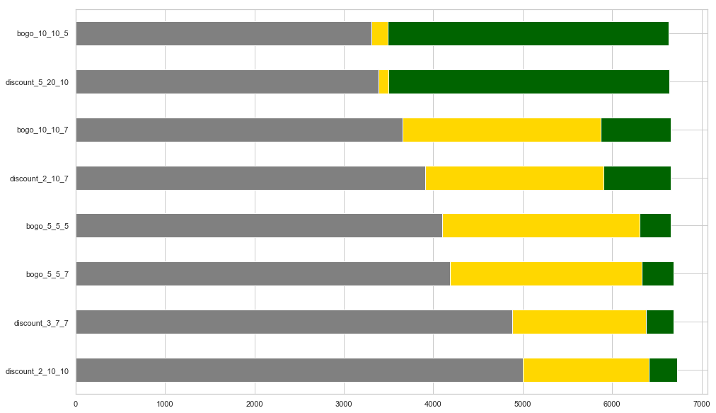

```python
fig = plt.figure(figsize=(16,10))
df[df.event=='offer received']['offer_id_mapped'].value_counts().plot.barh(color='darkgreen')
# received.groupby(['offer_id'])['OfferViewed'].value_counts().plot.barh(color='red')
df[df.event=='offer viewed']['offer_id_mapped'].value_counts().plot.barh(color='gold')
df[df.event=='offer completed']['offer_id_mapped'].value_counts().plot.barh(color='gray')
plt.show()
fig.savefig('OfferData.png')
```

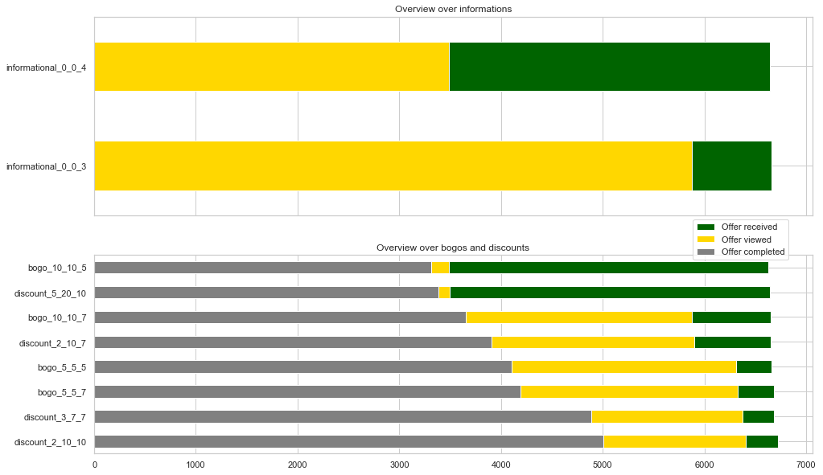

```python
f, axes = plt.subplots(2, 1, sharex=True, figsize=(16,10))
df[df.event=='offer received'][df.offer_id_mapped.isin(['informational_0_0_3','informational_0_0_4'])]['offer_id_mapped'].value_counts().plot.barh(color='darkgreen', ax=axes[0])
df[df.event=='offer viewed'][df.offer_id_mapped.isin(['informational_0_0_3','informational_0_0_4'])]['offer_id_mapped'].value_counts().plot.barh(color='gold', ax=axes[0])
axes[0].set_title('Overview over informations')

df[df.event=='offer received']['offer_id_mapped'].value_counts().plot.barh(color='darkgreen', ax=axes[1])
df[df.event=='offer viewed']['offer_id_mapped'].value_counts().plot.barh(color='gold', ax=axes[1])
df[df.event=='offer completed']['offer_id_mapped'].value_counts().plot.barh(color='gray', ax=axes[1])
axes[1].set_title('Overview over bogos and discounts')

plt.legend(['Offer received','Offer viewed','Offer completed'], loc=9, bbox_to_anchor=(0.9, 1.2))
f.savefig('OfferDistribution.png')
```

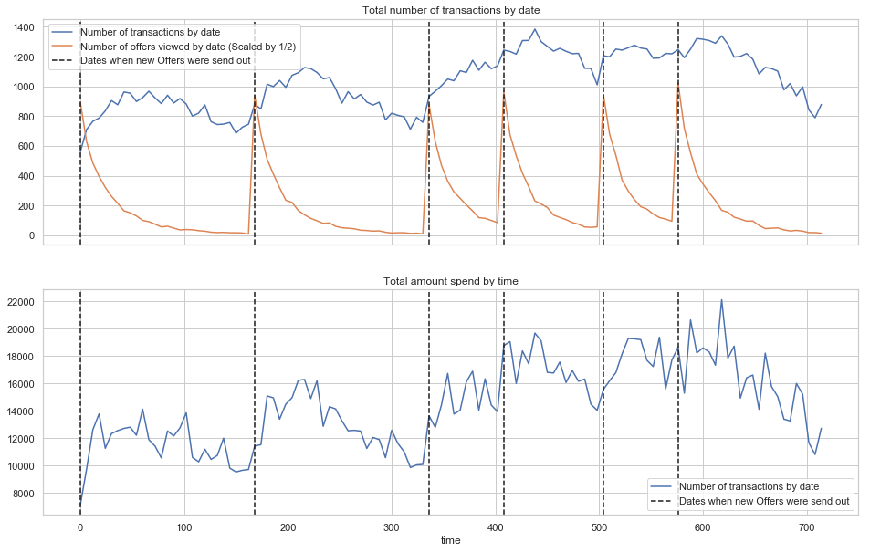

```python
f, axes = plt.subplots(2, 1, sharex=True, figsize=(16,10))
# axes[0].title('Total number of transactions by date')
axes[0].set_title('Total number of transactions by date')
axes[1].set_title('Total amount spend by time')
df[df.event=='transaction'].groupby(['time'])['amount'].count().plot(ax=axes[0])
xposition = df[df.event=='offer received'].time.unique()
# Scaled the Viewed time to better display it in the graph
axes[0] = df[df.event=='offer received'].groupby(['OfferViewedTime'])['time'].count().apply(lambda x: x/2).plot(ax=axes[0])
df[df.event=='transaction'].groupby(['time'])['amount'].sum().plot(ax=axes[1])
for xc in xposition:
    axes[0].axvline(x=xc, color='k', linestyle='--')
    axes[1].axvline(x=xc, color='k', linestyle='--')

axes[0].legend(['Number of transactions by date','Number of offers viewed by date (Scaled by 1/2)','Dates when new Offers were send out'])
axes[1].legend(['Number of transactions by date','Dates when new Offers were send out'])



f.savefig('NumberOfTransactionsbyDate.png')
```

**Regarding the diagram above called *Overview over informations* and *Overview over bogos and discounts***

In green are the total number of received offers shown for each category. Here we can see that roughly each offer was send out an equal number of times. What really is interesting is the diversity of viewed items and also of completed items. This means for example, that even though the first information was for the duration of 4 days it was viewed less. Also the it is interesting to see that the bogo_10_10_5 and discount_5_20_10 where almost always completed, when seen, while other offers where more likely to not be completed, even if seen.

**Finally**

To come back to the question, we already see here that differnt offers are received differently. Yet an important note here, is that generally speaking though, there is a direct correlation between the timing when an offer is received and the impact it has on the Total Amount spend.

# 4. Data modeling

In this chapter I will model the data. I decided to use a clustering algorithm, in order to answert question number 3. The following steps will be performed. First I will select a subsection of the previously prepared dataset. Reason being, that some attributes are helpful in general but can't be used to model the data.

Next I will scale the data using a Standardscaler.

With the scaled data I will perform dimensionality reduction, in order to ensure that there is no feature weighting in more then others. This will be done by PCA. My goal here will be to achieve above 90% Variability explained.

Next with the results of the PCA, I want to cluster the data. For this I will use the K-Means algorithm. The clusters will be added as an extra attribute to the original dataset.

And the results will be evaluated in the next step

**Note on improvements: The above proceedure seems reasonable, but in earlier Versions, I struggles with the clusters a lot. Reason for that was that I neither used a scaler nor did I use dimensionality reduction. Without those the result tend to be biased, towards certain attributes, such as income, that weights in more than others, as the value is simply higher**

```python
# Due to the prepartions done before the model currently has multiple NaNs where there was no entry to fill.
# For this reason I will replace all NaNs with a 0 in order to Model the data.
df.fillna(0, inplace=True)
```

```python
received = df[df.event=='offer received']
# Email will be excluded, because it has no correlation
features = received[['age', 'income', 'difficulty', 'duration',
                     'reward', 'gender_F', 'gender_M', 'gender_O',
                     'mobile', 'social', 'web',
                     'MemberSince', 'MembershipInMonths',
                     'OfferViewed', 'OfferViewedTime', 'OfferCompleted',
                     'OfferCompletedTime', 'TransactionInTime',
                     'TransactionTime', 'AmountDurProm',
                     'NumOfTransactions', 'bogo', 'discount',
                     'informational']]
```

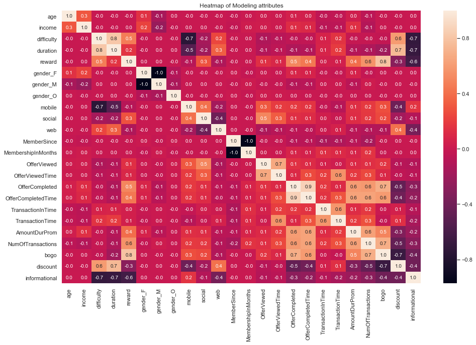

```python
f = plt.figure(figsize=(16,10))
sns.heatmap(features.corr(), annot=True, fmt='.1f')
plt.title('Heatmap of Modeling attributes')
f.savefig('Heatmap.png')
```

```python
from sklearn.decomposition import PCA
from sklearn.preprocessing import StandardScaler
scaled_feature = StandardScaler().fit_transform(features)
```

```python
pca = PCA(15)
pca.fit(scaled_feature)
```

```
PCA(copy=True, iterated_power='auto', n_components=15, random_state=None,
  svd_solver='auto', tol=0.0, whiten=False)
```

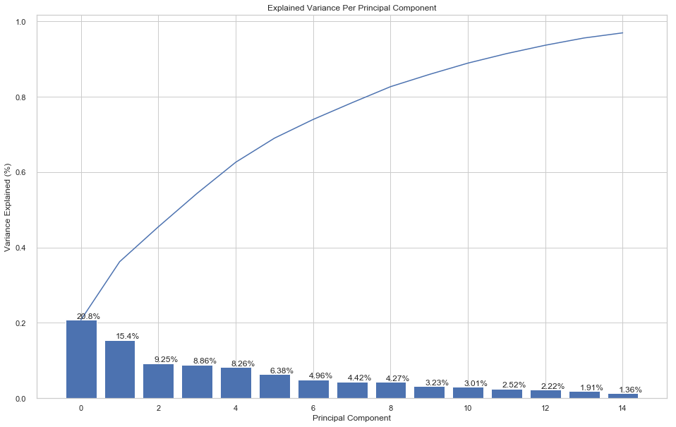

```python
scree_plot(pca)
```

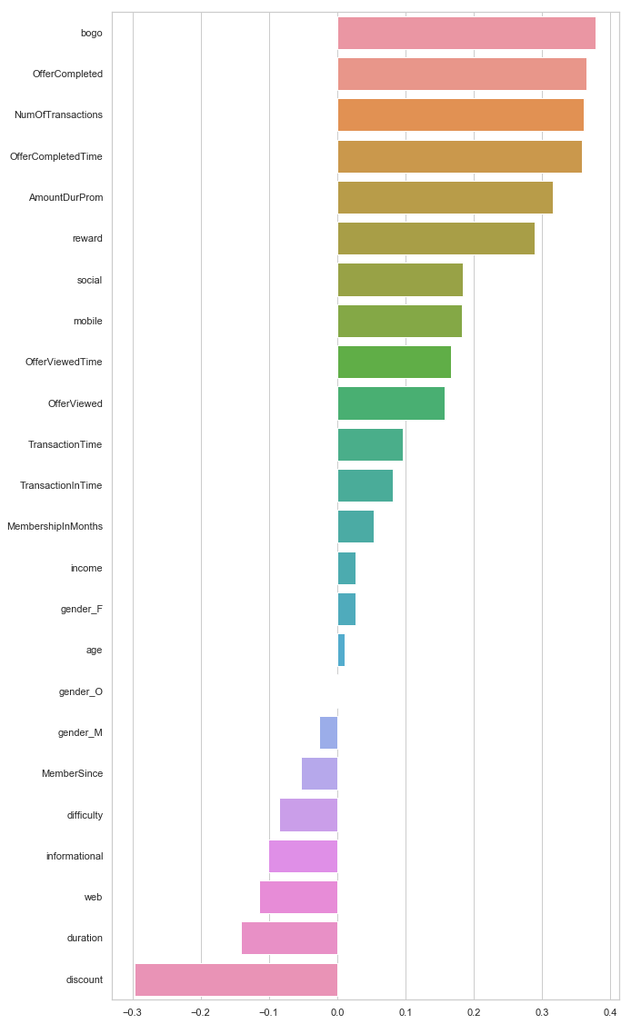

```python
sort_pca = sorted([(weight, label) for weight,label in zip(pca.components_[0], features.columns) ], reverse=True)
weights, feats = zip(*sort_pca)
weights, feats = list(weights), list(feats)
fig, ax = plt.subplots(figsize=(10,20))
ax = sns.barplot(weights, feats)
```

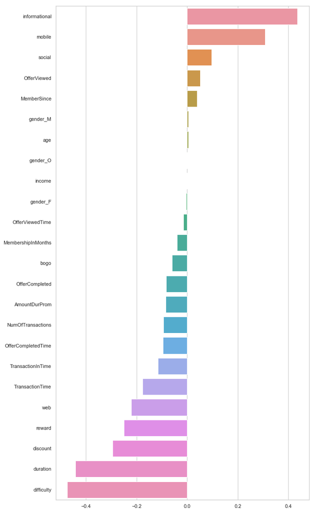

```python
sort_pca = sorted([(weight, label) for weight,label in zip(pca.components_[1], features.columns) ], reverse=True)
weights, feats = zip(*sort_pca)
weights, feats = list(weights), list(feats)
fig, ax = plt.subplots(figsize=(10,20))
ax = sns.barplot(weights, feats)
```

|  | Explained Variance | age | income | difficulty | duration | reward | gender_F | gender_M | gender_O | mobile | ... | OfferViewedTime | OfferCompleted | OfferCompletedTime | TransactionInTime | TransactionTime | AmountDurProm | NumOfTransactions | bogo | discount | informational |
| --- | --- | --- | --- | --- | --- | --- | --- | --- | --- | --- | --- | --- | --- | --- | --- | --- | --- | --- | --- | --- | --- |
| Dimension 1 | 0.2080 | 0.0112 | 0.0276 | -0.0855 | -0.1414 | 0.2886 | 0.0266 | -0.0269 | 0.0020 | 0.1823 | ... | 0.1668 | 0.3646 | 0.3585 | 0.082 | 0.0959 | 0.3157 | 0.3609 | 0.3791 | -0.2964 | -0.1009 |
| Dimension 2 | 0.1543 | 0.0040 | -0.0005 | -0.4741 | -0.4426 | -0.2494 | -0.0048 | 0.0043 | 0.0018 | 0.3074 | ... | -0.0149 | -0.0840 | -0.0959 | -0.115 | -0.1771 | -0.0850 | -0.0936 | -0.0602 | -0.2958 | 0.4362 |

2 rows × 25 columns

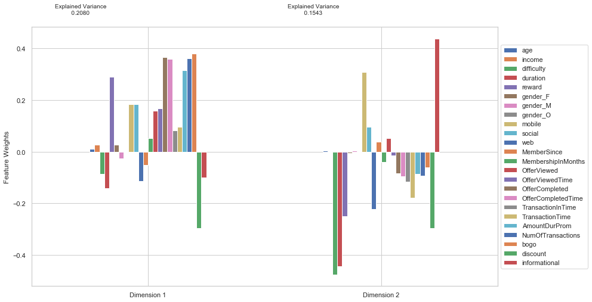

```python
pca_results(features, pca, 1, 0, 2)
```

|  | Explained Variance | age | income | difficulty | duration | reward | gender_F | gender_M | gender_O | mobile | ... | OfferViewedTime | OfferCompleted | OfferCompletedTime | TransactionInTime | TransactionTime | AmountDurProm | NumOfTransactions | bogo | discount | informational |
| --- | --- | --- | --- | --- | --- | --- | --- | --- | --- | --- | --- | --- | --- | --- | --- | --- | --- | --- | --- | --- | --- |
| Dimension 3 | 0.0926 | 0.1952 | 0.2564 | 0.0464 | -0.0037 | 0.0939 | 0.4636 | -0.4648 | 0.0141 | -0.0683 | ... | -0.2605 | 0.1100 | 0.0581 | -0.2511 | -0.2906 | 0.0590 | -0.0652 | 0.1099 | -0.0805 | -0.0359 |
| Dimension 4 | 0.0887 | 0.1695 | 0.2150 | -0.0633 | 0.0103 | -0.2010 | 0.4193 | -0.4199 | 0.0106 | 0.0319 | ... | 0.2541 | -0.0211 | 0.0253 | 0.2313 | 0.2777 | 0.0276 | -0.0457 | -0.2089 | 0.1311 | 0.0951 |

2 rows × 25 columns

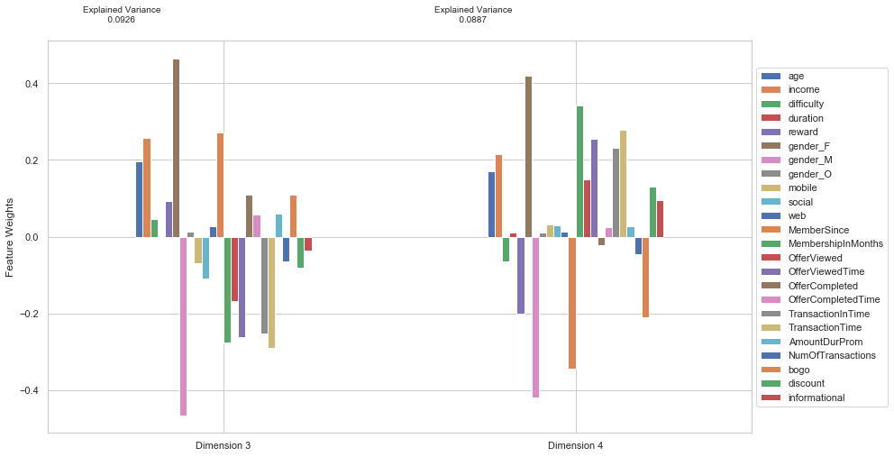

```python
pca_results(features, pca, 0, 2, 4)
```

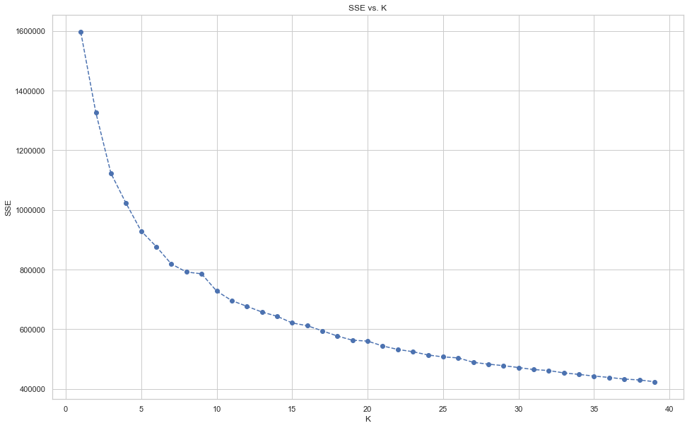

```python
scores = []
centers = list(range(1,40))

for center in centers:
    scores.append(get_kmeans_score(scaled_feature, center))

f = plt.figure(figsize=(16,10))
plt.plot(centers, scores, linestyle='--', marker='o', color='b');
plt.xlabel('K');
plt.ylabel('SSE');
plt.title('SSE vs. K');
f.savefig('Kneepoint.png')
```

Here I tried a very high number of centroids, the reason for that is to see if the data shows any anomaly or drop. As it did not I chose 10 centroids, to go from here. More centroids would cluster the data better, but the results of 10 was pretty good already.

```python
pca, X_pca = do_pca(15, scaled_feature)
```

```python
labels = fit_kmeans(X_pca, 10) #fit kmeans to get the labels
```

# 5. Evaluate the Results

The results of the fourth step have been the assignment of each row to a cluster. Moving on I will take from the prepared dataset the event==offer received portion and add the labels to it. The reason for this subsection is that during the Data Prepartion extra attributes have been created for the the rows that display the offers received.

Within this chapter, I will perform some analysis of the clusters, to see which cluster spends the most money. For this reason the attribute

AmountDurProm and NumberOfTransactions will be used.

**AmountDurProm**: This attribute shows the amount that was spent during the duration of an offer. The reason why this is important is the following. When a user buys something during that time period he might be affected by an offer. Because in reality, the data just shows that a user has seen or not seen an offer, but it might be the case that a user hasn't seen an offer, but he still heard from it from a collegue or a friend. So in order to cover such cases, it is safe to assume that all the amount spend during the duration of an ongoing offer might be influenced by it.

**NumberOfTransactions**: This attribute is in correlation to AmountDurProm. It keeps track on the numbers of transactions that occur during the timeframe of an active offer period. This has the same effect as described above.

```python
# Here I am taking the original dataset, with all attributes, as I no longer need to train the dataset
received['cluster'] = labels
```

```python
received.to_csv('finale_cluster.csv')
```

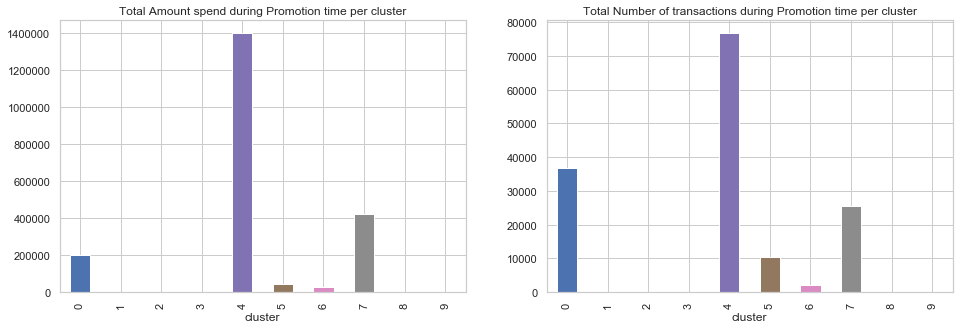

```python
f, axes = plt.subplots(1,2, figsize=(16,5))
axes[0].set_title('Total Amount spend during Promotion time per cluster')
received.groupby('cluster').AmountDurProm.sum().plot.bar(ax=axes[0])
axes[1].set_title('Total Number of transactions during Promotion time per cluster')
received.groupby('cluster').NumOfTransactions.sum().plot.bar(ax=axes[1])
f.savefig('ClusterAnalysis1.png')
```

```python
cluster = received[received.cluster.isin([0,4,5,7])]
```

```python
# Some reengineering from earlier
cluster['age_bin'] = pd.cut(cluster['age'], 10)
cluster['income_bin'] = pd.cut(cluster['income'], 10)
cluster['offer_id_mapped'] = cluster['offer_id'].map(remap)
```

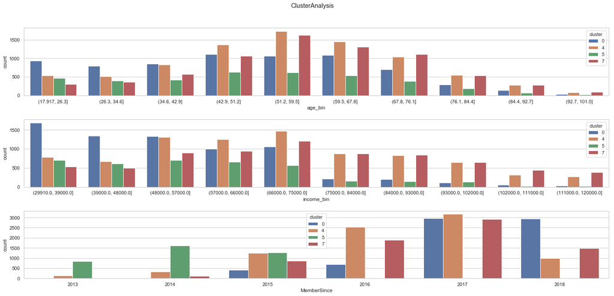

```python
f, axes = plt.subplots(3,1, figsize=(20,10))
f.tight_layout(rect=[0, 0.03, 1, 0.95], pad=3)
f.suptitle('ClusterAnalysis', fontsize="x-large")
sns.countplot(x='age_bin', hue='cluster', data=cluster, ax=axes[0])
sns.countplot(x='income_bin', hue='cluster', data=cluster, ax=axes[1])
sns.countplot(x='MemberSince', hue='cluster', data=cluster, ax=axes[2])
f.savefig('ClusterAnalysis_result.png')
```

```python
cluster.offer_id_mapped.unique()
```

```
array(['bogo_5_5_7', 'informational_0_0_3', 'bogo_10_10_7', 'bogo_5_5_5',
       'discount_2_10_7', 'informational_0_0_4', 'discount_2_10_10',
       'discount_3_7_7', 'discount_5_20_10', 'bogo_10_10_5'], dtype=object)
```

```python
cluster.columns
```

```
Index(['event', 'person', 'time', 'age', 'income', 'amount', 'offer_id',
       'difficulty', 'duration', 'reward', 'gender_F', 'gender_M', 'gender_O',
       'email', 'mobile', 'social', 'web', 'MemberSince', 'MembershipInMonths',
       'OfferViewed', 'OfferViewedTime', 'OfferCompleted',
       'OfferCompletedTime', 'TransactionInTime', 'TransactionTime',
       'AmountDurProm', 'NumOfTransactions', 'bogo', 'discount',
       'informational', 'offer_id_mapped', 'cluster', 'age_bin', 'income_bin'],
      dtype='object')
```

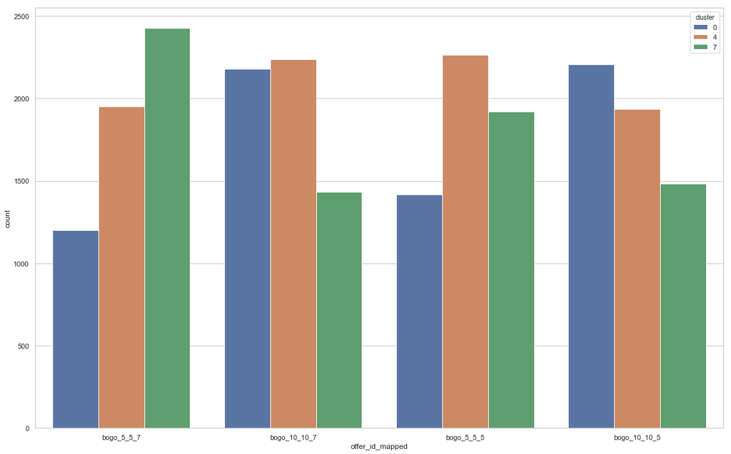

```python
cluster = received[received.cluster.isin([0,4,7])]
f = plt.figure(figsize=(16,10))
sns.countplot(x='offer_id_mapped', hue="cluster", data=cluster)
f.tight_layout()
f.savefig('FinalAnswer.png')
```

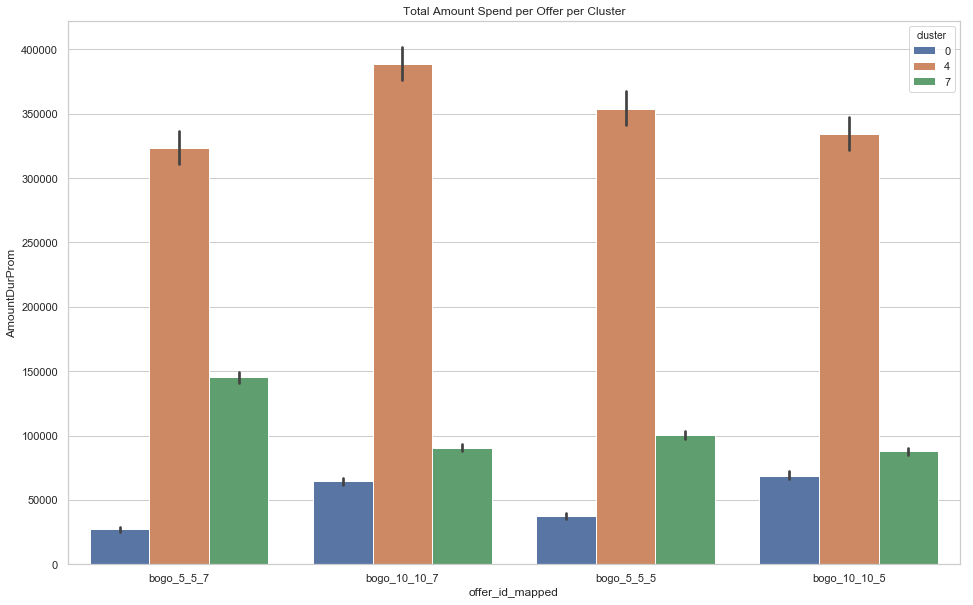

```python
f = plt.figure(figsize=(16,10))
sns.barplot(x='offer_id_mapped',y='AmountDurProm',hue='cluster',data=cluster, estimator=sum)
plt.title('Total Amount Spend per Offer per Cluster')
f.savefig('FinalSum.png')
```

# 6. Conclusion and Deployment

To conclude the results here. The cluster anlaysis was successful to identify a few things. First of, the clusters could be used to clearly seperate responding users from non responsive users. Which can be helpful for future ad campaigns, where responsive users can be focused. Furthermore the cluster analysis revealed that not all offers had the same impact on the Transaction amount spend afterwards. Therefore only bogos, do offer the wished impact on the amount spend. My inital estimation would be the following, based on some real life experiences. I have never been to Starbucks and saw some discount. I thing the reason for this is that people will still be willing to pay the prices currently set for their products.

But instead of getting a discount the bogo achieves a different psychological effect. As the prices are at a certain level and noone normally gets discounts, getting one completely free is a huge incentive as their product is already valued quite highly by users. Therefore the potential of getting one such high value item completely free is much more daunting for a user. This is much like the same with lottery, where the very high value item (high prize) money is so daunting for people, to spend money on basically a loose, just for the chance of winning.

**Possible Improvements** With the current approach a possible improvement could use a higher number of clusters. This would result in more work analysing the data, but the benefit would be a more diverse dataset. But what would that mean. The results have shown that the main contributer of amount spend during a promotion is in cluster number 4. Increasing the number of centroids wouid increase the number of clusters, which in fact would diversify the results even further. This could help to target users even better in the future.

Yet I think the problem in this project and in this task is that there are multiple parameters missing, that might influence the user more. One such feature that might be really helpful would be the amount spend reading the offer. Given that we are talking from a mobile app that should be technically feasible to implement. Another feature could be how often the offer was shared with friends, or how often was an offer reopened and read again, to keep it in mind. Another important maybe even crucial factor would be the activity time of this app. Like how often users use the app, if they even use the app. This might help give some insights on some behaviour. And the final feature would be if notifcations are used or not. As this might influence whether a users sees the offer or not, because I could imagine, that users might view an offer, wihtout opening the app through notifications, which was not captured within this data.